# Capitulo 2

### Faceting

Faceting crea tablas de gráficos dividiendo los datos en subgrupos y mostrando la misma gráfica para cada subgrupo.

Hay dos tipos: **grid** y **wrap**. **wrap** es el más útil.

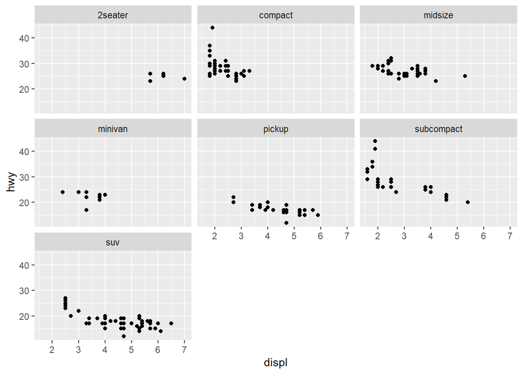

```r
ggplot(mpg, aes(displ, hwy)) +
  geom_point() +
  facet_wrap(~ class)
```

### Ejercicios

1. Use faceting to explore the 3-way relationship between fuel economy, engine size, and number of cylinders. How does faceting by number of cylinders change your assessement of the relationship between engine size and fuel economy?

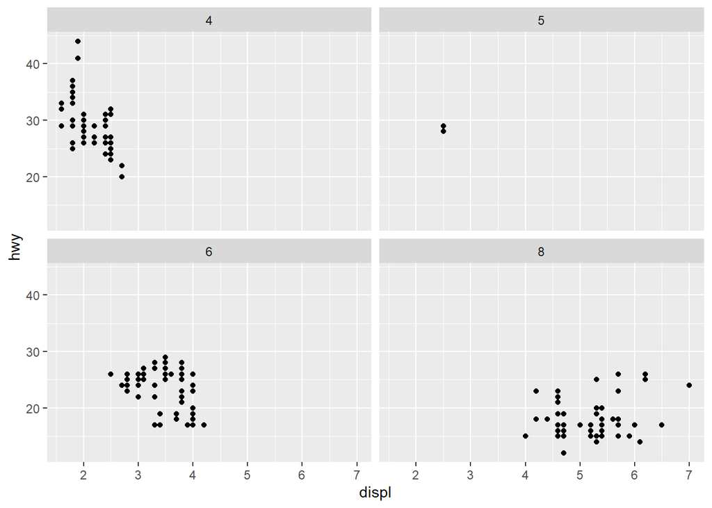

```r
ggplot(mpg, aes(displ, hwy)) +
  geom_point() +
  facet_wrap(~ cyl)
```

### Plot geoms

Las geometrias más usadas son:

- **geom_smooth()**: Grafíca una linea suavizada con su error estándar.
- **geom_bar()**: Grafíca la distribución de variables categóricas.
- **geom_histogram() y geom_freqpoly()**: Grafícan la distribución de variables continuas.
- **geom_boxplot()**: Grafíca el resúmen de la distribución de un conjunto de puntos.
- **geom_path() y geom_line()**: Grafícan una linea entre los puntos.